This was an exercise to replicate a map [a friend of mine](https://azuremarie.files.wordpress.com/2017/04/map_2.pdf) made in ArcGIS. However, the challenge for me was to use only R for the entire thing, as well as make the [entire process reproducable via code](https://github.com/maxpohlman/shiny-server/blob/master/Mapproj/Pollinator_Suitability_Map.r). Check it out:

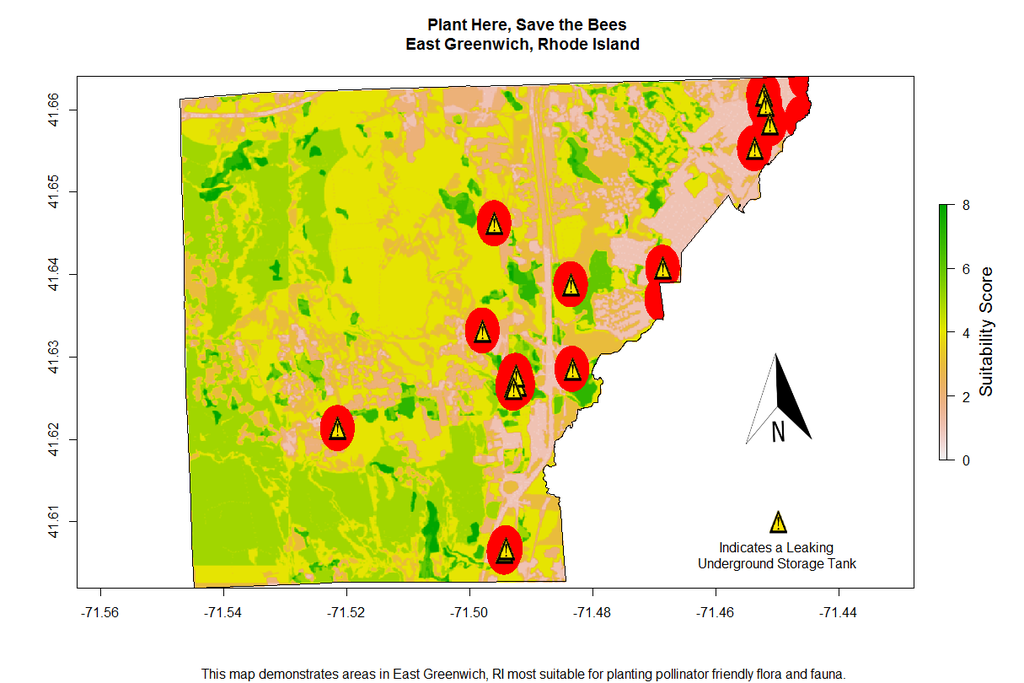

#### The criteria used for scoring planting areas are:

- Elevation higher than 125 feet (1 point)
- Road density below the town average (1 point)
- Soil designated as “Prime farmland” (3 points)
- Land classified as a forest, brushland, orchard, cropland, or wetland (2 points)
- Land classified as undeveloped, conserved, or protected (1 point)

For more information on the data I used, check out the [source code](https://github.com/maxpohlman/shiny-server/blob/master/Mapproj/Pollinator_Suitability_Map.r) which has links to all the datasets!

You’ll notice some slight differences between my map and the one I’m replicating, most of which came down to data sources:

- My data classified wetlands and forest/brushland/orchard/croplands as mutually exclusive. Thus my max score is 8 instead of 10 since land can’t be both a wetland and a forest/etc.
- We used different methods for road density. I used a raster for line density of roads and classified the cells that had a density of less than the mean as ‘Low Density’
- Instead of using terrain datasets, my elevation data was costructed from converting contours into polygons.
- I couldn’t find data for chemical spills so I used leaking underground storage tanks instead.